# Data Cleaning

Please go to Session on the RStudio Menu, and click on ‘Restart R and Clear Output’.

# CLEANING DATA

## Characteristics of a clean dataset

- Follows a tidy data structure
- Remove duplicate rows/values
- Error-free (e.g. free of misspellings)
- Variables should have appropriate data type. e.g. numeric, character, factor etc
- Factors (categorical/ ordinal) should have relevant levels
- Remove incorrect/ non-relevant outliers
- Missing data should be set as NA

## CLEANING DATA Exercise

1. Load the **tidyverse** libraries

```r
library(tidyverse)
```

2. Import `messy_data.csv` data from `/home/rstudio/inst/extdata`

```r
messy_data <- read_csv("../inst/extdata/messy_data.csv")
```

3. Use `head`, `summary` and `View` to view the data. Identify reasons why data is not in perfect order for analysis.

```r
head(messy_data)
```

```
## # A tibble: 6 x 18
##   Patient.id   Age Gender Date.of.birth Date.of.diagnos… Date.of.surgery Status
##   <chr>      <dbl> <chr>  <chr>         <chr>            <chr>           <chr>
## 1 TCGA_234      42 m      4/1/1968      4/1/2010         5-May-10        dead
## 2 TCGA_236      62 m      2/1/1948      2/1/2010         7-Mar-10        alive
## 3 TCGA_363      33 m      4/1/1979      4/1/2012         5-May-12        alive
## 4 TCGA 603      36 m      6/1/1976      6/1/2012         5-Jul-12        alive
## 5 tcga_049      90 m      3/1/1922      3/1/2012         4-Apr-12        dead
## 6 TCGA 604      46 f      9/1/1960      9/1/2006         5-Oct-06        dead
## # … with 11 more variables: Survival <dbl>, Censor <dbl>, Time.of.death <chr>,
## #   Identifier <dbl>, Classification <chr>, Histological.subtype <chr>,
## #   enzyme.level <dbl>, MUC1 <chr>, T <chr>, TNM <chr>, X <lgl>
```

```r
summary(messy_data)
```

```
##   Patient.id             Age           Gender          Date.of.birth
##  Length:25          Min.   : 6.00   Length:25          Length:25
##  Class :character   1st Qu.:36.00   Class :character   Class :character
##  Mode  :character   Median :46.00   Mode  :character   Mode  :character
##                     Mean   :51.11
##                     3rd Qu.:65.00
##                     Max.   :96.00
##                     NA's   :7
##  Date.of.diagnosis  Date.of.surgery       Status             Survival
##  Length:25          Length:25          Length:25          Min.   : 8.00
##  Class :character   Class :character   Class :character   1st Qu.:28.00
##  Mode  :character   Mode  :character   Mode  :character   Median :36.00
##                                                           Mean   :38.29
##                                                           3rd Qu.:53.00
##                                                           Max.   :64.00
##                                                           NA's   :8
##      Censor       Time.of.death        Identifier    Classification
##  Min.   :0.0000   Length:25          Min.   : 49.0   Length:25
##  1st Qu.:0.0000   Class :character   1st Qu.:603.2   Class :character
##  Median :0.0000   Mode  :character   Median :604.0   Mode  :character
##  Mean   :0.4706                      Mean   :518.7
##  3rd Qu.:1.0000                      3rd Qu.:604.0
##  Max.   :1.0000                      Max.   :604.0
##  NA's   :8                           NA's   :7
##  Histological.subtype  enzyme.level         MUC1                T
##  Length:25            Min.   :  0.090   Length:25          Length:25
##  Class :character     1st Qu.:  0.135   Class :character   Class :character
##  Mode  :character     Median :  0.240   Mode  :character   Mode  :character
##                       Mean   : 38.213
##                       3rd Qu.:  0.310
##                       Max.   :684.000
##                       NA's   :7
##      TNM               X
##  Length:25          Mode:logical
##  Class :character   NA's:25
##  Mode  :character
##
##
##
##
```

Also try `View(messy_data)`

```r
View(messy_data)
```

4. Remove the column *X*. There are only NAs present in the variable.

```r
messy_data %>% pull(X)
```

```
##  [1] NA NA NA NA NA NA NA NA NA NA NA NA NA NA NA NA NA NA NA NA NA NA NA NA NA
```

```r
messy_data <- messy_data %>% select(-X)
```

5. Remove observations with *Patient.id* marked as NA. Multiple missing rows need to be removed.

```r
tail(messy_data)
```

```
## # A tibble: 6 x 17
##   Patient.id   Age Gender Date.of.birth Date.of.diagnos… Date.of.surgery Status
##   <chr>      <dbl> <chr>  <chr>         <chr>            <chr>           <chr>
## 1 <NA>          NA <NA>   <NA>          <NA>             <NA>            <NA>
## 2 <NA>          NA <NA>   <NA>          <NA>             <NA>            <NA>
## 3 <NA>          NA <NA>   <NA>          <NA>             <NA>            <NA>
## 4 <NA>          NA <NA>   <NA>          <NA>             <NA>            <NA>
## 5 <NA>          NA <NA>   <NA>          <NA>             <NA>            <NA>
## 6 <NA>          NA <NA>   <NA>          <NA>             <NA>            <NA>
## # … with 10 more variables: Survival <dbl>, Censor <dbl>, Time.of.death <chr>,
## #   Identifier <dbl>, Classification <chr>, Histological.subtype <chr>,
## #   enzyme.level <dbl>, MUC1 <chr>, T <chr>, TNM <chr>
```

```r
messy_data <- messy_data %>% filter(!is.na(Patient.id))
```

6. *Patient.id* values are not consistent. *TCGA* as prefix is used in different forms. Use `str_replace_all` and `to_upper` to fix this.

```r
messy_data<- messy_data %>%
  mutate(Patient.id = toupper(messy_data$Patient.id)) %>%
  mutate(Patient.id =  str_replace_all(messy_data$Patient.id,"tcga", "TCGA")) %>%
  mutate(Patient.id =  str_replace_all(messy_data$Patient.id,"TCGA ", "TCGA_"))
```

7. Check categorical variables.

```r
messy_data %>% pull(Gender) %>% table()
```

```
## .
##  f  m
## 10  8
```

```r
messy_data %>% pull(Status) %>% table()
```

```
## .
## alive  dead
##     9     9
```

```r
messy_data %>% pull(Censor) %>% table()
```

```
## .
## 0 1
## 9 8
```

```r
messy_data %>% pull(Identifier) %>% table()
```

```
## .
##  49 234 236 363 603 604
##   1   1   1   1   1  13
```

```r
messy_data %>% pull(Classification) %>% table()
```

```
## .
## new_m42_cancer
##              1
```

```r
messy_data %>% pull(Histological.subtype) %>% table()
```

```
## .
##      invasive         MANEC      mucinous           NOS NOS/papillary
##             1             1             2            10             3
##     papillary
##             1
```

```r
messy_data %>% pull(MUC1) %>% table()
```

```
## .
##   ???     0 0bis1     1     2     3
##     1    10     1     1     3     1
```

```r
messy_data %>% pull(TNM) %>% table()
```

```
## .
## T1N0M0 T1N1M0 T2N0M0 T2N1M0 T3N0M0 T3N1M0
##      3      2     10      1      1      1
```

8. *Classification* is not an informative variables, so remove it.

```r
messy_data<-messy_data %>% select(-Classification)
```

9. *MUC1* has an entry = ???. Mark this as missing. Create a factor variable to ensure levels of factor *MUC1* are relevant (in ascending order).

```r
messy_data<-messy_data %>% mutate(MUC1=ifelse(MUC1=="???",NA,MUC1)) %>%
    mutate(MUC1=factor(MUC1, levels = c("0", "0bis1", "1", "2", "3")))
```

10. Checking numerical variables.

```r
messy_data %>% pull(Survival) %>% summary()
```

```
##    Min. 1st Qu.  Median    Mean 3rd Qu.    Max.    NA's
##    8.00   28.00   36.00   38.29   53.00   64.00       1
```

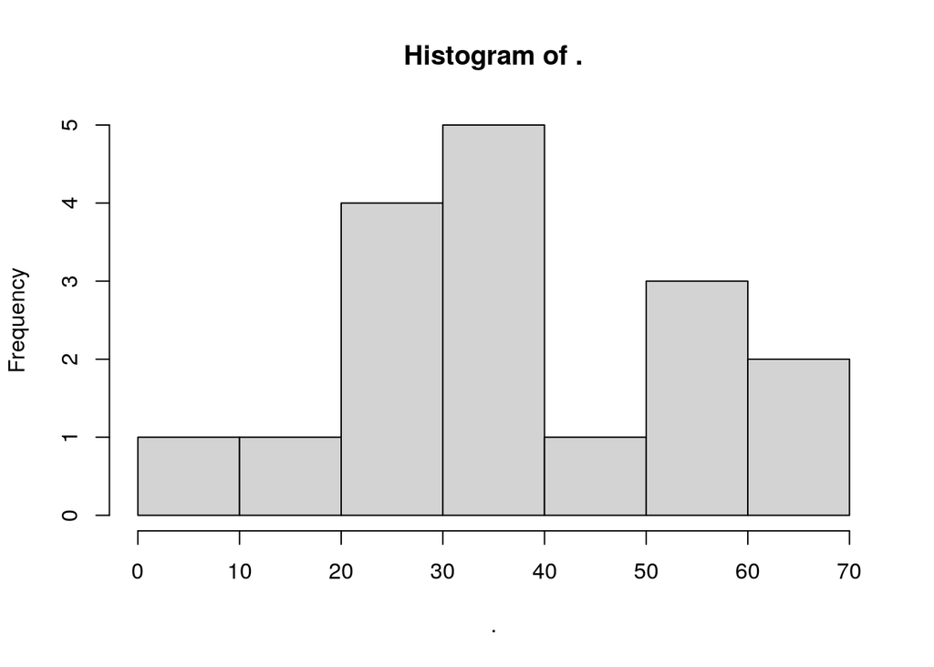

```r
messy_data %>% pull(Survival) %>% hist()
```

```r
messy_data %>% pull(enzyme.level) %>% summary()
```

```
##    Min. 1st Qu.  Median    Mean 3rd Qu.    Max.
##   0.090   0.135   0.240  38.213   0.310 684.000
```

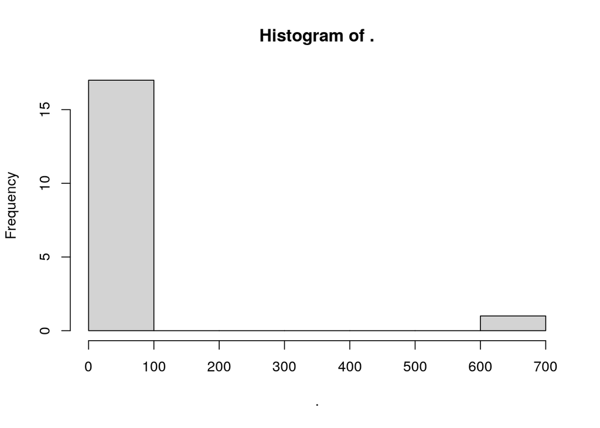

```r
messy_data %>% pull(enzyme.level) %>% hist()
```

```r
messy_data %>% pull(Age) %>% summary()
```

```
##    Min. 1st Qu.  Median    Mean 3rd Qu.    Max.
##    6.00   36.00   46.00   51.11   65.00   96.00
```

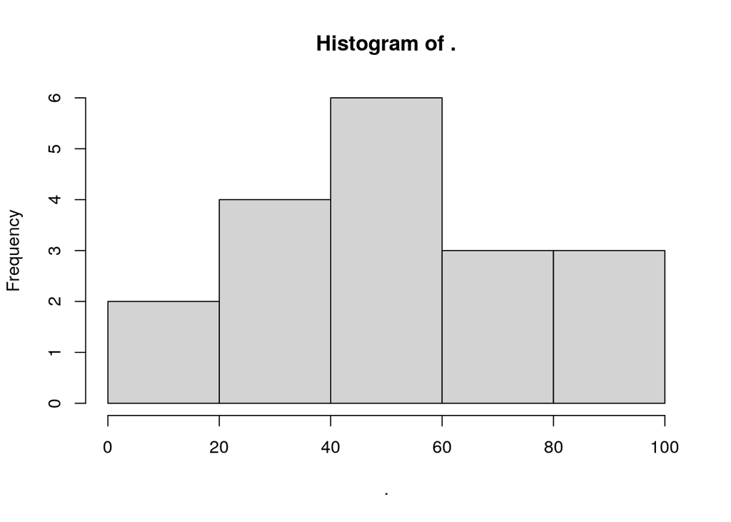

```r
messy_data %>% pull(Age) %>% hist()
```

11. *enzyme.level* has an incorrect outlier. Identify and mark it as missing.

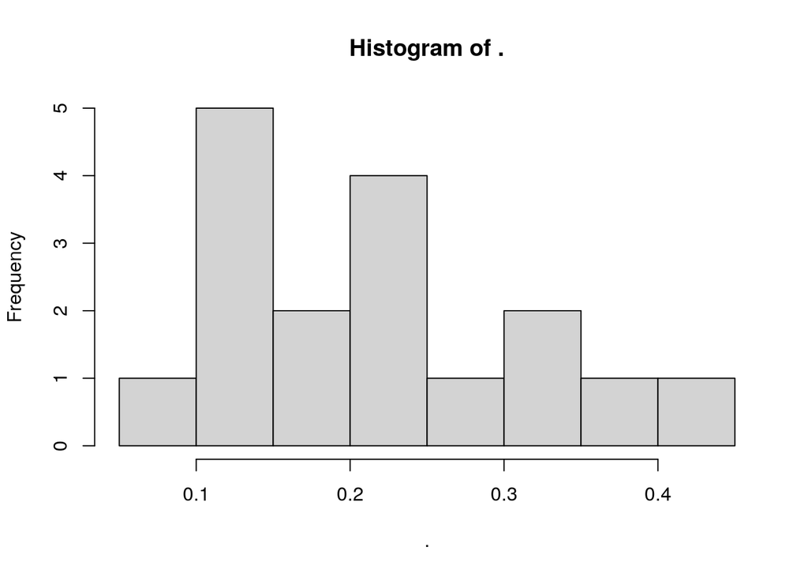

```r
messy_data<-messy_data %>% mutate(enzyme.level=ifelse(enzyme.level>600,NA,enzyme.level))
messy_data %>% pull(enzyme.level) %>% hist()
```

### Move PAST OPTIONAL CLEANING STEPS directly to MANIPULATING DATA Exercise below.

### <<— OPTIONAL CLEANING STEPS —>>

12. *TNM* contains 3 variables (columns) in 1. Use `substr` to extract the relevant position of string to get T,N and M. Convert them into **integer** type using `as.integer`.

```r
messy_data<-messy_data %>% mutate(T=as.integer(substr(TNM, 2, 2)),
         N=as.integer(substr(TNM, 4, 4)),
         M=as.integer(substr(TNM, 6, 6)))

messy_data %>% pull(TNM) %>% table()
```

```
## .
## T1N0M0 T1N1M0 T2N0M0 T2N1M0 T3N0M0 T3N1M0
##      3      2     10      1      1      1
```

```r
messy_data %>% pull(T) %>% table()
```

```
## .
##  1  2  3
##  5 11  2
```

```r
messy_data %>% pull(N) %>% table()
```

```
## .
##  0  1
## 14  4
```

```r
messy_data %>% pull(M) %>% table()
```

```
## .
##  0
## 18
```

13. Dates are not in **Date** format.

```r
summary(messy_data)
```

```
##   Patient.id             Age           Gender          Date.of.birth
##  Length:18          Min.   : 6.00   Length:18          Length:18
##  Class :character   1st Qu.:36.00   Class :character   Class :character
##  Mode  :character   Median :46.00   Mode  :character   Mode  :character
##                     Mean   :51.11
##                     3rd Qu.:65.00
##                     Max.   :96.00
##
##  Date.of.diagnosis  Date.of.surgery       Status             Survival
##  Length:18          Length:18          Length:18          Min.   : 8.00
##  Class :character   Class :character   Class :character   1st Qu.:28.00
##  Mode  :character   Mode  :character   Mode  :character   Median :36.00
##                                                           Mean   :38.29
##                                                           3rd Qu.:53.00
##                                                           Max.   :64.00
##                                                           NA's   :1
##      Censor       Time.of.death        Identifier    Histological.subtype
##  Min.   :0.0000   Length:18          Min.   : 49.0   Length:18
##  1st Qu.:0.0000   Class :character   1st Qu.:603.2   Class :character
##  Median :0.0000   Mode  :character   Median :604.0   Mode  :character
##  Mean   :0.4706                      Mean   :518.7
##  3rd Qu.:1.0000                      3rd Qu.:604.0
##  Max.   :1.0000                      Max.   :604.0
##  NA's   :1
##   enzyme.level       MUC1          T             TNM
##  Min.   :0.0900   0    :10   Min.   :1.000   Length:18
##  1st Qu.:0.1300   0bis1: 1   1st Qu.:1.250   Class :character
##  Median :0.2400   1    : 1   Median :2.000   Mode  :character
##  Mean   :0.2259   2    : 3   Mean   :1.833
##  3rd Qu.:0.2800   3    : 1   3rd Qu.:2.000
##  Max.   :0.4300   NA's : 2   Max.   :3.000
##  NA's   :1
##        N                M
##  Min.   :0.0000   Min.   :0
##  1st Qu.:0.0000   1st Qu.:0
##  Median :0.0000   Median :0
##  Mean   :0.2222   Mean   :0
##  3rd Qu.:0.0000   3rd Qu.:0
##  Max.   :1.0000   Max.   :0
##
```

```r
messy_data<-messy_data %>%
mutate(Date.of.surgery= as.Date(Date.of.surgery, format="%d-%b-%y")) %>%
mutate(Date.of.birth= as.Date(Date.of.birth, format="%d/%m/%Y")) %>%
mutate(Date.of.diagnosis= as.Date(Date.of.diagnosis, format="%d/%m/%Y")) %>%
mutate(Time.of.death= as.Date(Time.of.death, format="%d-%b-%y"))
summary(messy_data)
```

```
##   Patient.id             Age           Gender          Date.of.birth
##  Length:18          Min.   : 6.00   Length:18          Min.   :1908-01-03
##  Class :character   1st Qu.:36.00   Class :character   1st Qu.:1945-04-09
##  Mode  :character   Median :46.00   Mode  :character   Median :1958-07-08
##                     Mean   :51.11                      Mean   :1956-05-27
##                     3rd Qu.:65.00                      3rd Qu.:1974-01-05
##                     Max.   :96.00                      Max.   :1999-01-12
##
##  Date.of.diagnosis    Date.of.surgery         Status             Survival
##  Min.   :2002-01-06   Min.   :2002-07-05   Length:18          Min.   : 8.00
##  1st Qu.:2010-01-02   1st Qu.:2010-03-21   Class :character   1st Qu.:28.00
##  Median :2012-01-03   Median :2012-04-19   Mode  :character   Median :36.00
##  Mean   :2010-11-05   Mean   :2011-04-27                      Mean   :38.29
##  3rd Qu.:2014-01-02   3rd Qu.:2014-03-28                      3rd Qu.:53.00
##  Max.   :2015-01-12   Max.   :2016-01-04                      Max.   :64.00
##                                                               NA's   :1
##      Censor       Time.of.death          Identifier    Histological.subtype
##  Min.   :0.0000   Min.   :2006-11-10   Min.   : 49.0   Length:18
##  1st Qu.:0.0000   1st Qu.:2010-08-17   1st Qu.:603.2   Class :character
##  Median :0.0000   Median :2012-02-10   Median :604.0   Mode  :character
##  Mean   :0.4706   Mean   :2011-11-19   Mean   :518.7
##  3rd Qu.:1.0000   3rd Qu.:2013-09-26   3rd Qu.:604.0
##  Max.   :1.0000   Max.   :2015-01-08   Max.   :604.0
##  NA's   :1        NA's   :10
##   enzyme.level       MUC1          T             TNM
##  Min.   :0.0900   0    :10   Min.   :1.000   Length:18
##  1st Qu.:0.1300   0bis1: 1   1st Qu.:1.250   Class :character
##  Median :0.2400   1    : 1   Median :2.000   Mode  :character
##  Mean   :0.2259   2    : 3   Mean   :1.833
##  3rd Qu.:0.2800   3    : 1   3rd Qu.:2.000
##  Max.   :0.4300   NA's : 2   Max.   :3.000
##  NA's   :1
##        N                M
##  Min.   :0.0000   Min.   :0
##  1st Qu.:0.0000   1st Qu.:0
##  Median :0.0000   Median :0
##  Mean   :0.2222   Mean   :0
##  3rd Qu.:0.0000   3rd Qu.:0
##  Max.   :1.0000   Max.   :0
##
```

14. *Age* has an incorrect outlier. Age of 6 is too low. Correct it using the Dates.

```r
messy_data %>% pull(Age) %>% summary()
```

```
##    Min. 1st Qu.  Median    Mean 3rd Qu.    Max.
##    6.00   36.00   46.00   51.11   65.00   96.00
```

```r
messy_data %>% pull(Age) %>% table()
```

```
## .
##  6 16 26 33 36 42 45 46 56 62 66 76 86 90 96
##  1  1  1  1  2  1  1  2  2  1  1  1  1  1  1
```

```r
messy_data<-messy_data %>% mutate(Age=difftime(Date.of.diagnosis,Date.of.birth, units = "days")) %>%
  mutate(Age=round(Age/365, digits = 0))

messy_data %>% pull(Age) %>% summary()
```

```
##   Length    Class     Mode
##       18 difftime  numeric
```

```r
messy_data %>% pull(Age) %>% table()
```

```
## .
## 16 26 33 36 42 45 46 56 62 66 76 86 90 96
##  1  1  1  2  1  1  2  2  1  2  1  1  1  1
```

### <<— OPTIONAL CLEANING STEPS COMPLETE —>>

## MANIPULATING DATA Exercise

1. Focus on *alive* *females*. `Status` and `Gender` are categorical variables with the respective tags. What is the average and standard deviation of `enzyme.level` for this subset of patients?

Hint: Use `filter` and `summarize` and use the `na.rm = TRUE` argument when computing the average and standard deviation. You can also filter the NA values using `filter`.

2. Using a pipe, assign the average to a numeric variable `ref_avg`. Hint: Use the code similar to above and then `pull`.

3. Now report the min and max values for the same group.

4. Compute the average and standard deviation for females, but for each Status group separately rather than only *alive* as in question 1. Hint: rather than filtering by Status and gender, filter by `Gender` and then use `group_by`.

5. We can actually combine both summaries for males and females into one line of code. This is because `group_by` permits us to group by more than one variable. Obtain one big summary table using `group_by(Status, Gender)`.

6. For males, compare enzyme.level across Histological subtypes as reported in the `Histological.subtype` variable. Order the resulting table from lowest to highest average `enzyme.level`.